# Titanic

2024-08-21

# The data-set

Data Dictionary

Variable  
survival: Survival 0 = No, 1 = Yes

pclass: Ticket class 1 = 1st, 2 = 2nd, 3 = 3rd

sex: Sex

Age: Age in years

sibsp: # of siblings / spouses aboard the Titanic

parch: # of parents / children aboard the Titanic

ticket: Ticket number

fare: Passenger fare

cabin :Cabin number

embarked: Port of Embarkation C = Cherbourg, Q = Queenstown, S = Southampton

pclass: A proxy for socio-economic status (SES)

1st = Upper 2nd = Middle 3rd = Lower

age: Age is fractional if less than 1. If the age is estimated, is it in the form of xx.5

sibsp: The dataset defines family relations in this way…

Sibling = brother, sister, stepbrother, stepsister

Spouse = husband, wife (mistresses and fiancés were ignored)

parch: The dataset defines family relations in this way…

Parent = mother, father

Child = daughter, son, stepdaughter, stepson

Some children travelled only with a nanny, therefore parch=0 for them.

# TRAIN DATA

| PassengerId | Survived | Pclass | Name | Sex | Age | SibSp | Parch | Ticket | Fare | Cabin | Embarked |
| --- | --- | --- | --- | --- | --- | --- | --- | --- | --- | --- | --- |
| 1 | 0 | 3 | Braund, Mr. Owen Harris | male | 22.00 | 1 | 0 | A/5 21171 | 7.2500 |  | S |
| 2 | 1 | 1 | Cumings, Mrs. John Bradley (Florence Briggs Thayer) | female | 38.00 | 1 | 0 | PC 17599 | 71.2833 | C85 | C |
| 3 | 1 | 3 | Heikkinen, Miss. Laina | female | 26.00 | 0 | 0 | STON/O2. 3101282 | 7.9250 |  | S |
| 4 | 1 | 1 | Futrelle, Mrs. Jacques Heath (Lily May Peel) | female | 35.00 | 1 | 0 | 113803 | 53.1000 | C123 | S |
| 5 | 0 | 3 | Allen, Mr. William Henry | male | 35.00 | 0 | 0 | 373450 | 8.0500 |  | S |
| 6 | 0 | 3 | Moran, Mr. James | male | NA | 0 | 0 | 330877 | 8.4583 |  | Q |
| 7 | 0 | 1 | McCarthy, Mr. Timothy J | male | 54.00 | 0 | 0 | 17463 | 51.8625 | E46 | S |
| 8 | 0 | 3 | Palsson, Master. Gosta Leonard | male | 2.00 | 3 | 1 | 349909 | 21.0750 |  | S |
| 9 | 1 | 3 | Johnson, Mrs. Oscar W (Elisabeth Vilhelmina Berg) | female | 27.00 | 0 | 2 | 347742 | 11.1333 |  | S |
| 10 | 1 | 2 | Nasser, Mrs. Nicholas (Adele Achem) | female | 14.00 | 1 | 0 | 237736 | 30.0708 |  | C |

[output cut: 881 more lines]

# Dimension of the data-set

```
[1] 891  12
```

# Variables in the data-set

```
'data.frame':   891 obs. of  12 variables:
 $ PassengerId: int  1 2 3 4 5 6 7 8 9 10 ...
 $ Survived   : int  0 1 1 1 0 0 0 0 1 1 ...
 $ Pclass     : int  3 1 3 1 3 3 1 3 3 2 ...
 $ Name       : chr  "Braund, Mr. Owen Harris" "Cumings, Mrs. John Bradley (Florence Briggs Thayer)" "Heikkinen, Miss. Laina" "Futrelle, Mrs. Jacques Heath (Lily May Peel)" ...
 $ Sex        : chr  "male" "female" "female" "female" ...
 $ Age        : num  22 38 26 35 35 NA 54 2 27 14 ...
 $ SibSp      : int  1 1 0 1 0 0 0 3 0 1 ...
 $ Parch      : int  0 0 0 0 0 0 0 1 2 0 ...
 $ Ticket     : chr  "A/5 21171" "PC 17599" "STON/O2. 3101282" "113803" ...
 $ Fare       : num  7.25 71.28 7.92 53.1 8.05 ...
 $ Cabin      : chr  "" "C85" "" "C123" ...
 $ Embarked   : chr  "S" "C" "S" "S" ...
```

# Column Names

```
 [1] "PassengerId" "Survived"    "Pclass"      "Name"        "Sex"
 [6] "Age"         "SibSp"       "Parch"       "Ticket"      "Fare"
[11] "Cabin"       "Embarked"
```

### **We remove the 1st,4th,9th and 11th column from the data-set**

### **We replace the NA values in the Age column with the mean of that column and convert the character variables into factor variables.**

### **In the dataset, we remove the empty cells from the ‘Embark’ column**

# PLOTS

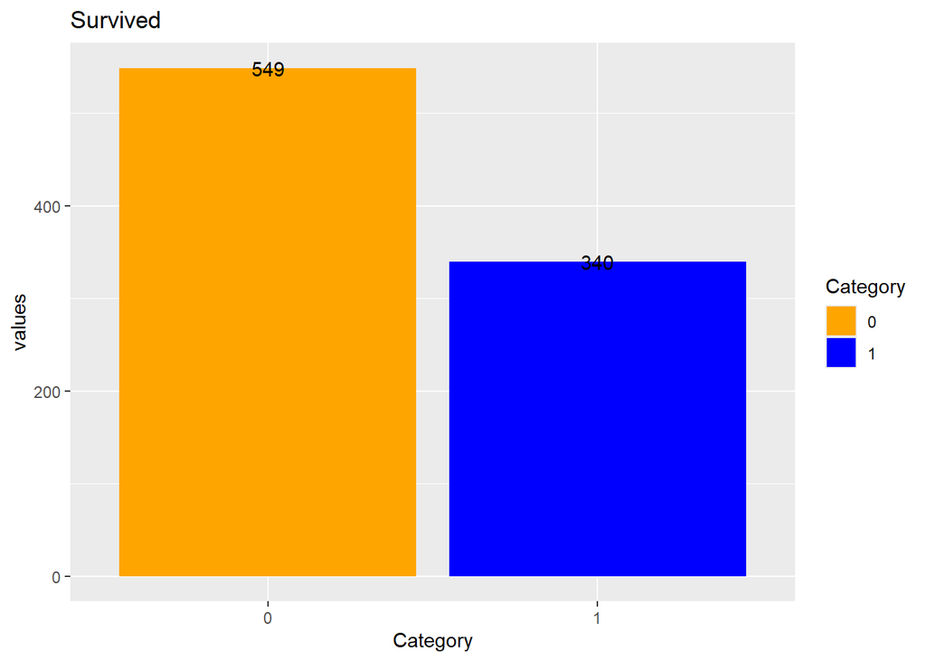

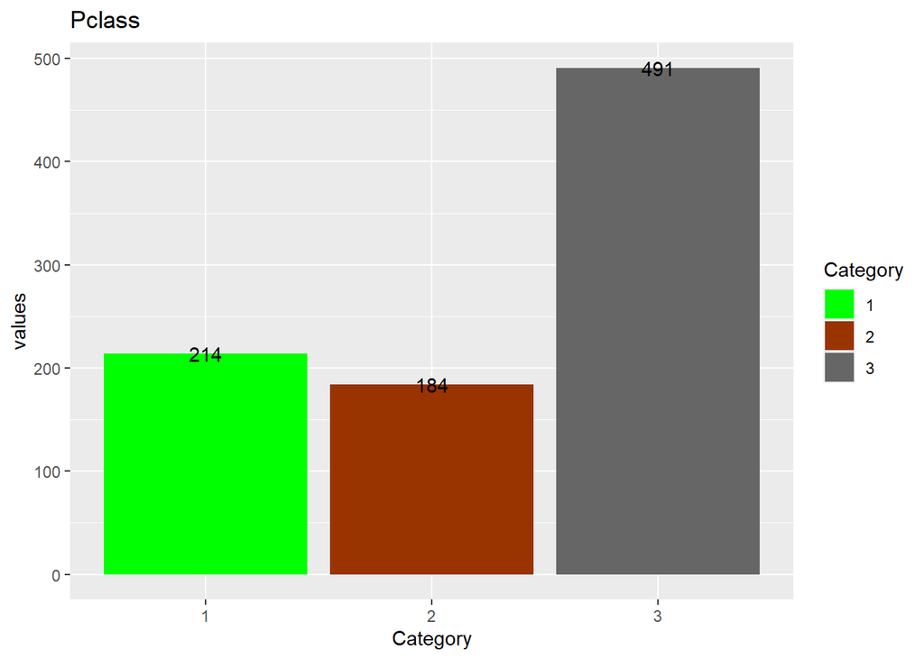

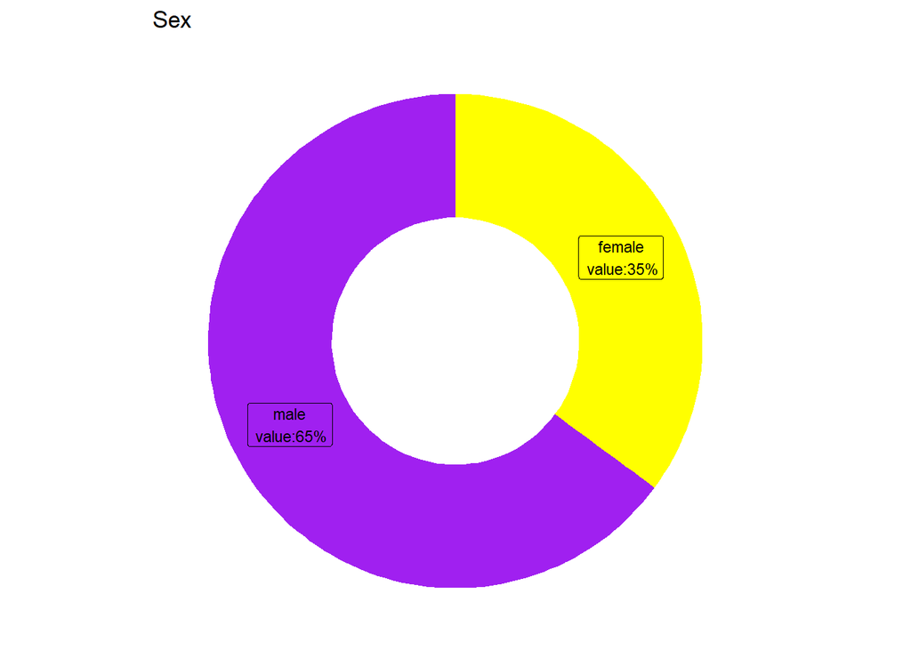

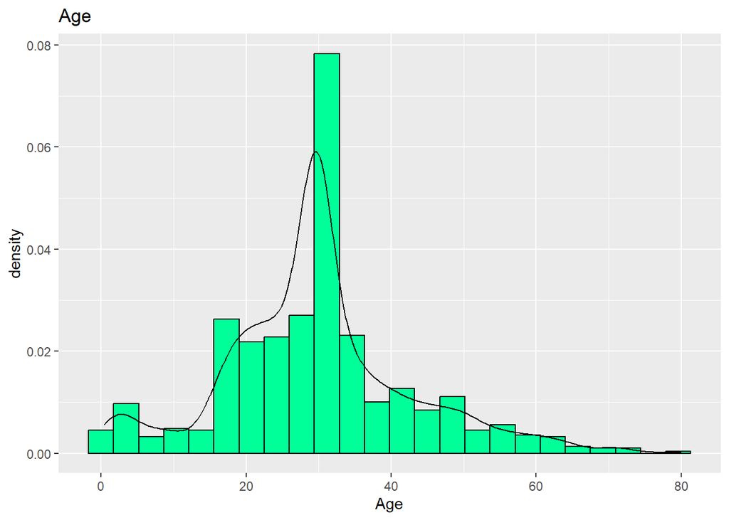

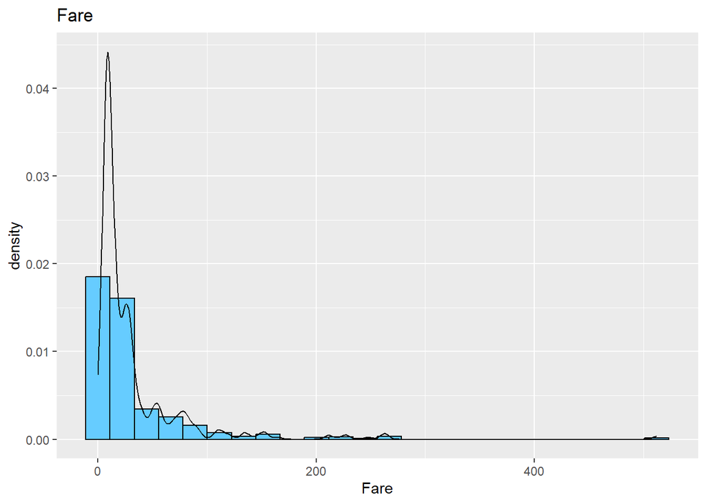

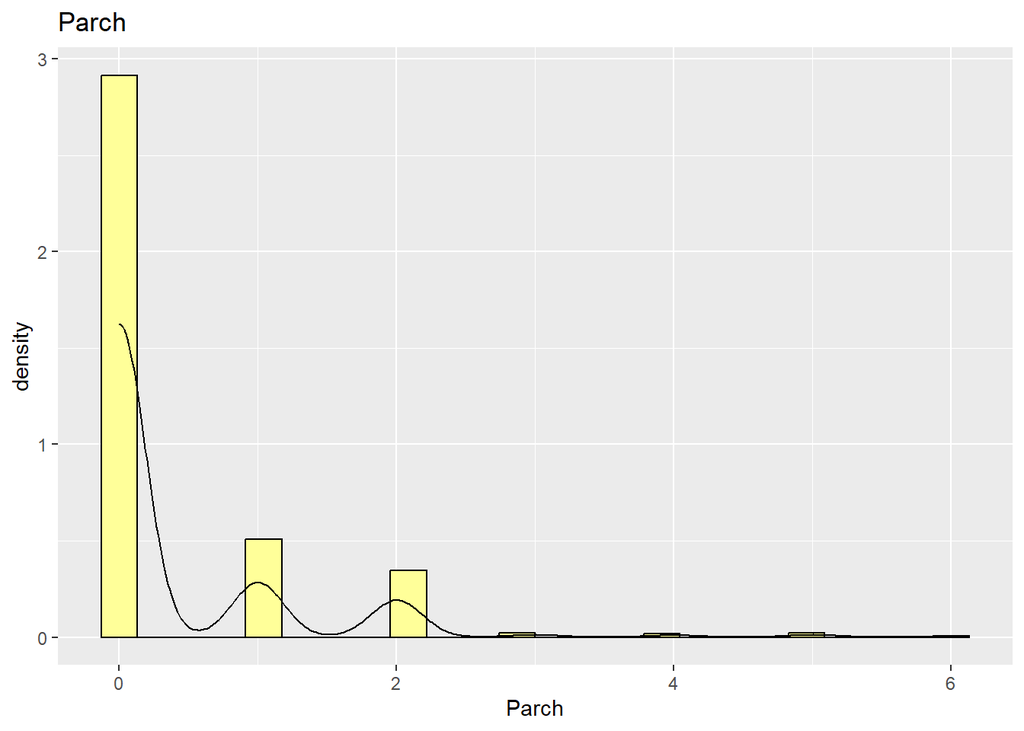

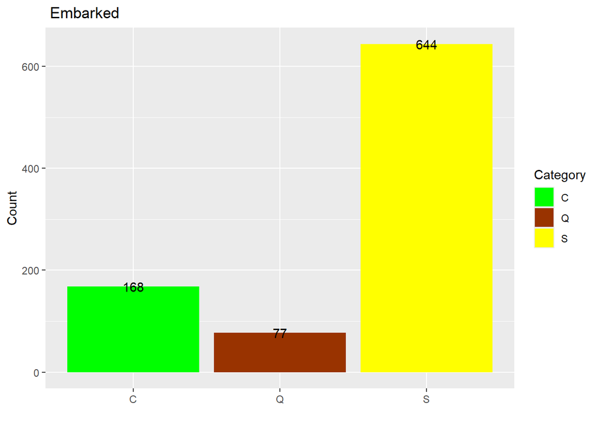

### *Since our response variable is binary, taking only the values 0 and 1, we use a logistic regression model.*

```
Call:
glm(formula = Survived ~ Pclass + Sex + Age + SibSp + Parch +
    Fare + Embarked, family = "binomial", data = ndata)

Coefficients:
             Estimate Std. Error z value Pr(>|z|)
(Intercept)  4.102784   0.476303   8.614  < 2e-16 ***
Pclass2     -0.924047   0.297882  -3.102  0.00192 **
Pclass3     -2.149626   0.297749  -7.220 5.21e-13 ***
Sexmale     -2.709611   0.201336 -13.458  < 2e-16 ***
Age         -0.039320   0.007888  -4.984 6.21e-07 ***
SibSp       -0.322143   0.109545  -2.941  0.00327 **
Parch       -0.095061   0.119028  -0.799  0.42450
Fare         0.002261   0.002462   0.918  0.35842
EmbarkedQ   -0.029839   0.381534  -0.078  0.93766
EmbarkedS   -0.445754   0.239730  -1.859  0.06297 .
---
Signif. codes:  0 '***' 0.001 '**' 0.01 '*' 0.05 '.' 0.1 ' ' 1

(Dispersion parameter for binomial family taken to be 1)

    Null deviance: 1182.82  on 888  degrees of freedom
Residual deviance:  783.74  on 879  degrees of freedom
AIC: 803.74

Number of Fisher Scoring iterations: 5
```

*We can see that ‘Pclass2’, ‘Pclass3’, ‘SexMale’, ‘Age’, and ‘SibSp’ are statistically significant, as their p-values are less than 0.05.*

*To improve the fit of our model we use AIC backward method.*

### *Backward elimination based on the Akaike Information Criterion(AIC)*

```
Start:  AIC=803.74
Survived ~ Pclass + Sex + Age + SibSp + Parch + Fare + Embarked

           Df Deviance     AIC
- Parch     1   784.38  802.38
- Fare      1   784.65  802.65
<none>          783.74  803.74
- Embarked  2   788.16  804.16
- SibSp     1   793.85  811.85
- Age       1   810.58  828.58
- Pclass    2   843.57  859.57
- Sex       1  1010.80 1028.80

Step:  AIC=802.38
Survived ~ Pclass + Sex + Age + SibSp + Fare + Embarked

           Df Deviance     AIC
- Fare      1   785.03  801.03
<none>          784.38  802.38
- Embarked  2   789.08  803.08
- SibSp     1   797.02  813.02
- Age       1   811.03  827.03
- Pclass    2   847.53  861.53
- Sex       1  1016.06 1032.06

Step:  AIC=801.03
Survived ~ Pclass + Sex + Age + SibSp + Embarked

           Df Deviance     AIC
<none>          785.03  801.03
- Embarked  2   790.30  802.30
- SibSp     1   797.02  811.02
- Age       1   812.43  826.43
- Pclass    2   882.25  894.25
- Sex       1  1022.23 1036.23
```

*We have selected the variables ‘Embarked’, ‘SibSp’, ‘Age’, ‘Pclass’, and ‘Sex’ for our regression model.*

### **Half-Normal Probability (hnp) Plot**

```
Binomial model
```

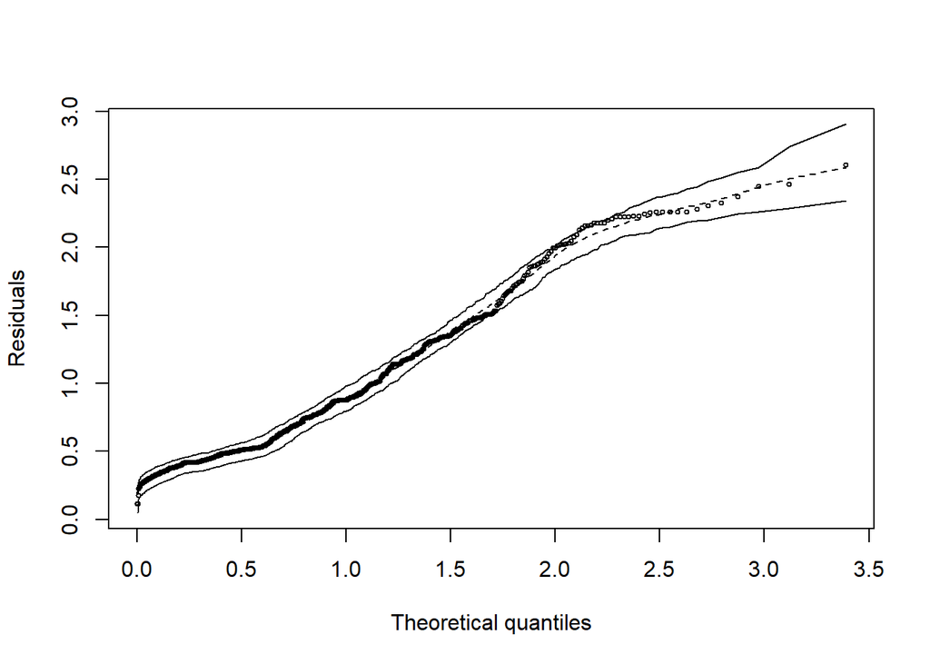

*Most of the residuals fall within these confidence bands, suggesting that the model is capturing the majority of the variability in the data accurately.*

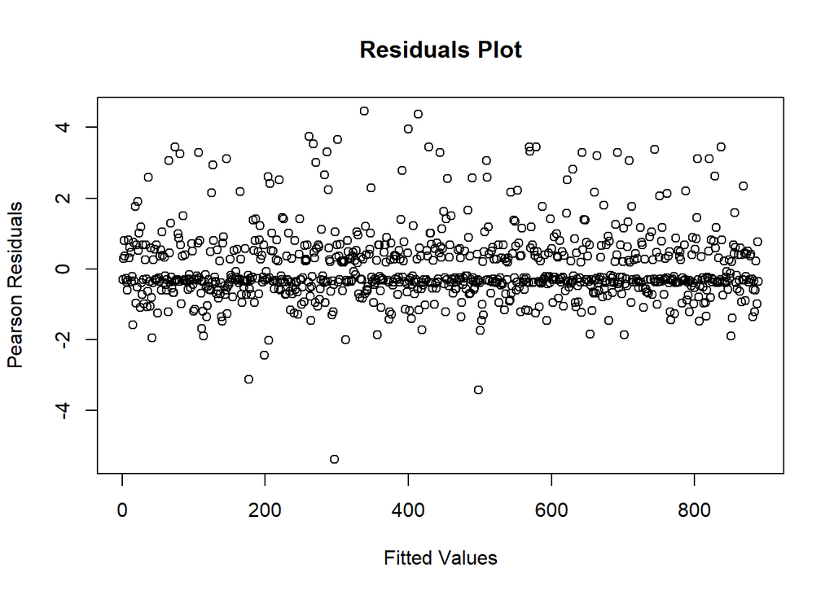

### **Receiver Operator Characteristic (ROC) Curve and Area Under the Curve (AUC)**

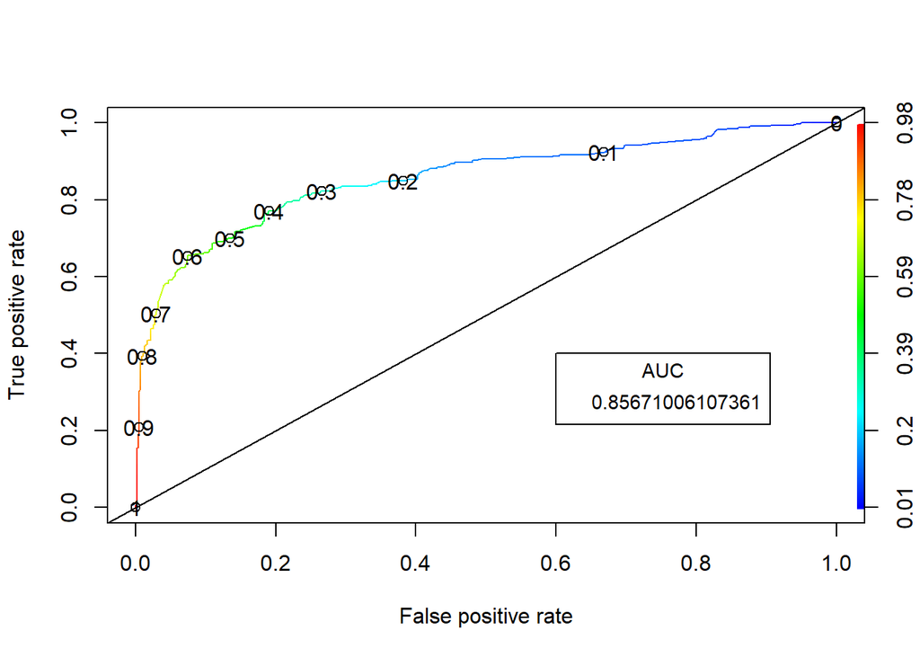

*The model’s AUC is 0.8567, indicating good predictive performance.*

# TEST DATA

| PassengerId | Pclass | Name | Sex | Age | SibSp | Parch | Ticket | Fare | Cabin | Embarked |
| --- | --- | --- | --- | --- | --- | --- | --- | --- | --- | --- |
| 892 | 3 | Kelly, Mr. James | male | 34.50 | 0 | 0 | 330911 | 7.8292 |  | Q |
| 893 | 3 | Wilkes, Mrs. James (Ellen Needs) | female | 47.00 | 1 | 0 | 363272 | 7.0000 |  | S |
| 894 | 2 | Myles, Mr. Thomas Francis | male | 62.00 | 0 | 0 | 240276 | 9.6875 |  | Q |
| 895 | 3 | Wirz, Mr. Albert | male | 27.00 | 0 | 0 | 315154 | 8.6625 |  | S |
| 896 | 3 | Hirvonen, Mrs. Alexander (Helga E Lindqvist) | female | 22.00 | 1 | 1 | 3101298 | 12.2875 |  | S |
| 897 | 3 | Svensson, Mr. Johan Cervin | male | 14.00 | 0 | 0 | 7538 | 9.2250 |  | S |
| 898 | 3 | Connolly, Miss. Kate | female | 30.00 | 0 | 0 | 330972 | 7.6292 |  | Q |
| 899 | 2 | Caldwell, Mr. Albert Francis | male | 26.00 | 1 | 1 | 248738 | 29.0000 |  | S |
| 900 | 3 | Abrahim, Mrs. Joseph (Sophie Halaut Easu) | female | 18.00 | 0 | 0 | 2657 | 7.2292 |  | C |
| 901 | 3 | Davies, Mr. John Samuel | male | 21.00 | 2 | 0 | A/4 48871 | 24.1500 |  | S |

[output cut: 408 more lines]

# PREDICTION

|  | PassengerId | Survived |
| --- | --- | --- |
| 1 | 892 | 0 |
| 2 | 893 | 0 |
| 3 | 894 | 0 |
| 4 | 895 | 0 |
| 5 | 896 | 0 |
| 6 | 897 | 0 |
| 7 | 898 | 1 |
| 8 | 899 | 0 |
| 9 | 900 | 1 |
| 10 | 901 | 0 |

[output cut: 408 more lines]